# Chapter 17: UML Class Diagrams

ENG3091: lecture notes

Author

Affiliation

Khiem Nguyen

University of Glasgow

**NoteHow we use these notes**

A UML class diagram rarely fits on a single slide, so this chapter has no slides: we work through these notes directly in the lecture. They come as an HTML page and a PDF.

# 1 What is a UML class diagram?

The **Unified Modeling Language (UML)** is a standard way of drawing software designs. A **class diagram** shows a program’s classes, what each class contains, and how the classes are related: exactly the relationships from Chapters 14 and 16.

A good class diagram lets someone write the code without asking you what you meant. That’s the point of having rules.

# 2 A note on conventions

You’ll find UML class diagrams on many websites, in textbooks and in drawing tools. The figures in these notes come from three places:

- [Visual Paradigm’s UML class diagram tutorial](https://www.visual-paradigm.com/guide/uml-unified-modeling-language/uml-class-diagram-tutorial/);
- [GeeksforGeeks’ article on UML class diagrams](https://www.geeksforgeeks.org/system-design/unified-modeling-language-uml-class-diagrams/);
- diagrams drawn with **Mermaid**, a text-based diagram tool built into Quarto (see the source file `chap_17.qmd`).

These sources don’t all draw things the same way. For example:

- GeeksforGeeks distinguishes a **directed association** (solid line, open arrow) from a plain association, and labels a dependency «use»; Visual Paradigm doesn’t.
- Some figures put the class with the diamond on the left, others on the right. Either way, the diamond sits at the **whole**.
- Types may come after the name (`length : int`, the UML standard) or before it (`int length`, as in C++). Mermaid accepts both.
- Visual Paradigm writes C++-style types such as `Class6*` for a pointer; others write only the class name.
- Abstract classes and methods may be shown in *italics*, with the stereotype «abstract», or (in Mermaid) with an asterisk: `draw()*`.
- Tools colour their boxes and arrowheads differently. Colours carry no meaning.

**ImportantThe rule in this course**

**Any convention is acceptable, in your coursework and in the exam, as long as it follows the same principles and creates no unnecessary confusion.** In practice:

1. Each class is a box: its name, then its attributes, then its operations.
2. Visibility uses `+` (public), `-` (private) and `#` (protected).
3. Relationships follow the usual line styles: solid or dashed lines; a diamond at the *whole*, filled for composition and hollow for aggregation; a hollow triangle pointing at the *parent* (or interface).
4. Multiplicities are written at the ends of a relationship.
5. **Be consistent** within one diagram, and if you use anything unusual, label it.

If someone else could build the right C++ classes from your diagram without asking you a question, your diagram is good.

# 3 Class notation

A class represents a concept that encapsulates **state** (attributes) and **behaviour** (operations). Each attribute has a type, and each operation has a **signature**. Only the class **name** is mandatory.

## 3.1 Class structure

A UML class box has three compartments:

1. **the class name**, at the top;
2. **the attributes**, in the middle: these become **data members** in C++;
3. **the operations**, at the bottom: these become **member functions**.

```
classDiagram
    class Shape{
        -length
        +get_length()
        +set_length()
    }
```

Without types or signatures

```
classDiagram
    class Shape{
        -length: int
        +get_length() int
        +set_length(n: int) void
    }
```

With types and signatures

Figure 1: The same class, drawn with less and with more detail.

- **Attribute types** follow a colon: `-length : int`.
- **Return types** follow a colon at the end of the operation: `+get_length() : int`.
- **Parameter types** follow a colon after each parameter’s name: `+set_length(n : int) : void`.

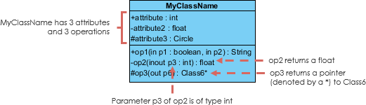

A class with typed attributes and operations. Source: [Visual Paradigm](https://www.visual-paradigm.com/guide/uml-unified-modeling-language/uml-class-diagram-tutorial/).

|  | Without signatures | With full signatures |
| --- | --- | --- |
| Attribute | `-length` | `-length : int` |
| Getter | `+get_length()` | `+get_length() : int` |
| Setter | `+set_length()` | `+set_length(n : int) : void` |

## 3.2 Visibility

The symbol in front of an attribute or operation gives its **visibility**, which is its access level (Chapter 11):

- `+` means **public**;
- `-` means **private**;
- `#` means **protected** (Chapter 14).

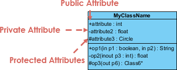

Attributes with different visibility. Source: [Visual Paradigm](https://www.visual-paradigm.com/guide/uml-unified-modeling-language/uml-class-diagram-tutorial/).

## 3.3 Parameter direction

UML can mark each parameter as `in`, `out` or `inout`, written before the parameter’s name. C++ has no such keywords; the parameter type says it instead:

| UML | Direction | Meaning | In C++ (Chapter 07) |
| --- | --- | --- | --- |
| `in` (the default) | caller to operation | the operation only reads the value | pass by value, or by `const` reference: `void f(const Fraction& x)` |
| `out` | operation to caller | the operation fills in a value for the caller | pass by non-`const` reference: `void f(int& result)` |
| `inout` | both ways | the operation reads the value, then changes it | pass by non-`const` reference: `void f(int& x)` |

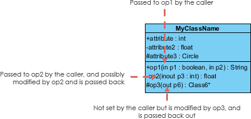

Parameter directions in a class. Source: [Visual Paradigm](https://www.visual-paradigm.com/guide/uml-unified-modeling-language/uml-class-diagram-tutorial/).

## 3.4 Perspectives

The same diagram can be read at different levels of detail:

- **conceptual**: the concepts in the problem domain;
- **specification**: the interfaces of the classes (what they offer);
- **implementation**: how the classes implement those interfaces.

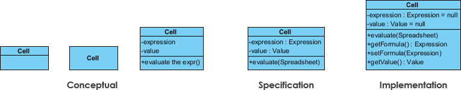

Perspectives of a class diagram. Source: [Visual Paradigm](https://www.visual-paradigm.com/guide/uml-unified-modeling-language/uml-class-diagram-tutorial/).

# 4 Relationships between classes

UML isn’t just pretty pictures. Used correctly, a diagram says precisely how the code should be written, and code written from it reflects the designer’s intent.

We’ve met all of these relationships already: inheritance (Chapter 14), realization of an interface (Chapter 15), and composition, aggregation, association and dependency (Chapter 16). Here’s how two websites draw them. Notice the small differences, as discussed in Section 2:

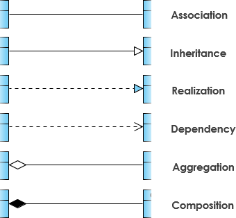

Source: [Visual Paradigm](https://www.visual-paradigm.com/guide/uml-unified-modeling-language/uml-class-diagram-tutorial/).

[figure not shown]

Source: [GeeksforGeeks](https://www.geeksforgeeks.org/system-design/unified-modeling-language-uml-class-diagrams/).

And here they are in Mermaid:

```
classDiagram
direction BT
classA --|> classB : Inheritance
classC --* classD : Composition
classE --o classF : Aggregation
classG -- classH : Association
classK ..> classL : Dependency
classM ..|> classN : Realization
```

We’ll go through them from the weakest to the strongest, using the classes from Chapter 16.

## 4.1 Dependency (“uses a”)

A **dependency** is the weakest relationship: one class *uses* another for a moment, as a parameter or a local variable, without keeping it. If the class it uses changes, it may have to change too.

- **Logic:** “class A uses class B to do a task.”
- **Notation:** a **dashed** line with an open arrow, pointing at the class being used.
- **Example (Chapter 16):** `Point` uses `std::ostream` in its `operator<<`. Likewise, a `Printer` uses a `Document` to print, but doesn’t own it.

```
classDiagram
    direction LR
    class Point
    class ostream
    Point ..> ostream : uses
```

## 4.2 Association (“knows a”)

An **association** is a structural link between two otherwise unrelated classes. It can be **unidirectional** (one class knows about the other) or **bidirectional** (both know about each other).

- **Logic:** “class A is associated with class B.”
- **Notation:** a **solid** line. With an open arrowhead, it’s a *directed* association: only the class at the tail knows about the other. With no arrowhead, it’s bidirectional.
- **Example (Chapter 16):** a `Doctor` and a `Patient`. They know about each other, but neither owns the other.

```
classDiagram
    direction LR
    class Doctor
    class Patient
    Doctor "0..*" -- "0..*" Patient : treats
```

## 4.3 Aggregation (“has a”)

An **aggregation** is a whole–part relationship in which the parts can exist independently of the whole.

- **Logic:** “class A has a class B, but B can live without A.”
- **Notation:** a solid line with a **hollow diamond** at the **whole**.
- **Example (Chapter 16):** a `Department` and its `Teacher`s. Closing the department doesn’t destroy the teachers. Likewise a `Library` and its `Book`s.

```
classDiagram
    direction LR
    class Department
    class Teacher
    Department o-- Teacher
```

## 4.4 Composition (“part of”)

A **composition** is a strong whole–part relationship: the whole manages the part’s lifetime. Destroy the whole, and the parts go with it.

- **Logic:** “class B is an integral part of class A.”
- **Notation:** a solid line with a **filled diamond** at the **whole**.
- **Example (Chapter 16):** a `Creature` and its `Point2D` location. Likewise a `House` and its `Room`s: demolish the house, and the rooms are gone.

```
classDiagram
    direction LR
    class Creature
    class Point2D
    Creature *-- Point2D : location
```

## 4.5 Inheritance, or generalization (“is a”)

**Inheritance** means a derived (child) class inherits the attributes and operations of its base (parent) class: it’s a specialized version of a more general concept.

- **Logic:** “class B is a kind of class A.”
- **Notation:** a solid line with a **hollow triangle** pointing at the **parent**.
- **Example (Chapter 14):** a `Lecturer` is a `UniPerson`, and so is a `Student`.

```
classDiagram
    direction BT
    class UniPerson
    class Lecturer
    class Student
    UniPerson <|-- Lecturer
    UniPerson <|-- Student
```

## 4.6 Realization (“implements”)

**Realization** connects an **interface** to a class that implements it. The class *realizes* the contract that the interface defines. In C++, an interface is an abstract class with only pure virtual functions (Chapter 15).

- **Logic:** “class A implements everything interface B promises.”
- **Notation:** a **dashed** line with a **hollow triangle** pointing at the interface.
- **Example (Chapter 15):** `Circle` and `Rectangle` implement the `Shape` interface.

```
classDiagram
    direction BT
    class Shape {
        <<interface>>
        +area() double
        +name() string_view
    }
    class Circle
    class Rectangle
    Shape <|.. Circle
    Shape <|.. Rectangle
```

**NoteRealization or inheritance?**

Strictly, realization is for **interfaces**. A class derived from an abstract class that *also* has data or implemented functions (like Chapter 15’s `Animal`) is drawn with ordinary inheritance: a solid line. Many websites and tools blur this distinction. Following Section 2, either is accepted, as long as you’re consistent.

## 4.7 Abstract classes

An abstract class can’t be instantiated (Chapter 15), and the diagram should make that visible. There are two common ways:

- **italics**: the class name in *italics*, and each abstract (pure virtual) operation in *italics* too;
- **a stereotype**: the word «abstract» above the class name. It’s clearer in hand-drawn diagrams, where italics are hard to see.

```
classDiagram
    direction BT
    class Animal {
        <<abstract>>
        #name: string
        +get_name() string_view
        +speak()* string_view
    }
    class Cow {
        +speak() string_view
    }
    Animal <|-- Cow
```

In Mermaid, `speak()*` marks an abstract operation.

**TipAbstract classes in the paper exam**

Handwriting has no italics, so use either of these:

- write «abstract» (or `<<abstract>>`) above the class name;
- surround the name with asterisks, `*ClassName*`, as if it were italic (Markdown style).

## 4.8 Summary of relationships

| Relationship | In words | Lifetime | Notation |
| --- | --- | --- | --- |
| Dependency | “uses a” (for a moment) | independent | dashed line, open arrow (- - >) |
| Association | “knows a” | independent | solid line (──), with an open arrow if directed |
| Aggregation | “has a” | independent | solid line, hollow diamond at the whole (◇──) |
| Composition | “part of” | the whole manages the part | solid line, filled diamond at the whole (◆──) |
| Inheritance | “is a” | the derived object contains the base part | solid line, hollow triangle at the parent (──▷) |
| Realization | “implements” | (a contract) | dashed line, hollow triangle at the interface (- - ▷) |

# 5 Multiplicity

**Multiplicity** (often called **cardinality**) says how many objects of one class can be linked to one object of the other. It’s written at the ends of a relationship.

| Notation | Meaning | Example |
| --- | --- | --- |
| `0..1` | zero or one | an `Employee` may have a `Desk` |
| `1` | exactly one | a `Car` has exactly one `Engine` |
| `0..*` | zero or more | a `Folder` contains any number of `File`s |
| `1..*` | one or more | a `Team` has at least one `Player` |
| `*` | many | short for `0..*` |
| `n` | exactly n | a `Tricycle` has exactly `3` `Wheel`s |
| `m..n` | between m and n | a `Jury` has between `6` and `12` members |

## 5.1 Multiplicity examples

As discussed in Section 2, it’s fine to write an attribute’s type before its name, as below, or after it.

**Example 1.** A `Car` has four `Tire`s and one `Engine`: compositions with fixed multiplicities.

```
classDiagram
    direction LR
    class Car {
        +String model
        +start_engine()
    }
    class Tire {
        +int pressure
    }
    class Engine {
        +int horse_power
    }
    Car "1" *-- "4" Tire : has
    Car "1" *-- "1" Engine : has
```

**Example 2.** A `Library` holds any number of `Book`s and `CD`s: aggregations with “many”.

```
classDiagram
    direction BT
    class Library {
        +String branch_name
        +open()
    }
    class Book {
        +String isbn
        +String title
    }
    class CD {
        +String artist
        +int track_count
    }
    Library "1" o-- "0..*" Book : contains
    Library "1" o-- "0..*" CD : contains
```

**Example 3.** A `Doctor` treats many `Patient`s, and a `Patient` may see many `Doctor`s: a many-to-many association.

```
classDiagram
    direction LR
    class Doctor {
        +String name
        +String specialization
        +schedule_appointment()
    }
    class Patient {
        +String name
        +Date date_of_birth
        +view_medical_history()
    }
    Doctor "0..*" -- "0..*" Patient : treats
```

# 6 Larger examples

## 6.1 Flights, pilots and airports

`Flight`, `Pilot` and `Airport` are linked by **associations**:

- a `Pilot` *works* a `Flight`: a relationship of service, not a structural “part of”;
- an `Airport` hosts many `Flight`s, and each `Flight` departs from one `Airport` and arrives at another.

```
classDiagram
    class Flight {
        -String flight_number
        -DateTime departure_time
        +delay_flight(int minutes)
    }
    class Pilot {
        -String license_number
        +String name
        +get_flight_hours() double
    }
    class Airport {
        -String iata_code
        +String city
        +get_weather() String
    }
    Flight "0..*" -- "2" Pilot : flown by
    Flight "0..*" -- "1" Airport : departs from
    Flight "0..*" -- "1" Airport : arrives at
```

## 6.2 Departments, lecturers, students and courses

1. A `Department` has many `Lecturer`s.
2. A `Department` has many `Student`s.
3. A `Department` offers many `Course`s.
4. Several `Lecturer`s can teach one `Course`.
5. One `Lecturer` can teach several `Course`s.
6. One `Student` can take many `Course`s.
7. One `Course` can have many `Student`s.

Statements 1 to 3 describe “part of the department”: aggregations, since lecturers, students and courses don’t disappear if the department is reorganized. Statements 4 to 7 describe *providing* and *using* a service: associations.

**Note**

In everyday English we could say “has” for every one of these sentences. But a student rarely moves between departments during their studies, while lecturers change courses quite often. The lecturer–course and student–course links are interactions that come and go, which is what associations describe.

```
classDiagram
    class Department {
        -String name
        +add_lecturer(Lecturer l)
        +add_course(Course c)
    }
    class Lecturer {
        -String staff_id
        +String name
        +get_specialization() String
    }
    class Student {
        -String student_id
        +double gpa
    }
    class Course {
        -String course_id
        -int credits
    }
    Department "1" o-- "1..*" Lecturer : employs
    Department "1" o-- "1..*" Student : manages
    Department "1" o-- "1..*" Course : offers
    Lecturer "1..*" -- "1..*" Course : teaches
    Student "1..*" -- "1..*" Course : enrolled in
```

# 7 From the diagram to C++

This is what the exam asks of you: read a diagram, and write the classes, or the other way round. The usual translations:

| In the diagram | In C++ |
| --- | --- |
| class box | `class Name { ... };` |
| attribute `-x : double` | private data member `double x{};` |
| operation `+f(n : int) : void` | public member function `void f(int n);` |
| composition, multiplicity `1` | an ordinary data member: `Point2D location{};` |
| composition, multiplicity `*` | a `std::vector` of members, or `std::unique_ptr`s the class owns |
| aggregation | a reference or pointer to an outside object; for many, `std::vector<std::reference_wrapper<T>>` |
| association | pointer members (for many, `std::vector<const T*>`), on one or both sides |
| dependency | a function parameter or a local variable, not a member |
| inheritance | `class Derived : public Base` |
| realization | inherit from an interface and override every pure virtual function |
| abstract operation | a pure virtual function: `virtual double area() const = 0;` |

# 8 Past paper exam: shapes

```
classDiagram
    class Shape {
        <<abstract>>
        +draw()* void
    }
    class Point {
        +float x
        +float y
    }
    class Polygon {
        +draw() void
    }
    class Rectangle {
        -float width
        -float height
        -float theta
        +draw() void
    }
    class Square
    class Ellipse {
        -float width
        -float height
        -float theta
        +draw() void
    }
    class Circle

    Shape <|.. Polygon
    Shape <|.. Ellipse
    Polygon <|-- Rectangle
    Rectangle <|-- Square
    Ellipse <|-- Circle

    Polygon "1" *-- "3..*" Point : vertices
    Rectangle "1" *-- "1" Point : bottom-left corner
    Ellipse "1" *-- "1" Point : centre
```

- `Polygon` and `Ellipse` must list `+draw() : void`: they implement the abstract operation of `Shape`.
- Repeating `+draw() : void` in `Square` and `Circle` is allowed, but unnecessary: they inherit it.
- `Shape` is abstract, with an abstract `draw()`. The dashed realization arrows from `Polygon` and `Ellipse` follow the “implements” reading of Section 2. Solid inheritance arrows would be accepted too.

# 9 Keep learning

1. learncpp.com, Chapter 23: [object relationships](https://www.learncpp.com/cpp-tutorial/object-relationships/), the C++ side of every relationship drawn here.
2. Visual Paradigm’s [UML class diagram tutorial](https://www.visual-paradigm.com/guide/uml-unified-modeling-language/uml-class-diagram-tutorial/).
3. GeeksforGeeks on [UML class diagrams](https://www.geeksforgeeks.org/system-design/unified-modeling-language-uml-class-diagrams/).
4. The [Mermaid class diagram syntax](https://mermaid.js.org/syntax/classDiagram.html), to draw your own diagrams from text.